# Yulu_HypothesisTesting

```python
import numpy as np
import pandas as pd
import matplotlib.pyplot as plt
import seaborn as sns
import scipy.stats as stats

import warnings
warnings.simplefilter('ignore')
```

```python
df = pd.read_csv('https://d2beiqkhq929f0.cloudfront.net/public_assets/assets/000/001/428/original/bike_sharing.csv?1642089089')
df.head()
```

|  | datetime | season | holiday | workingday | weather | temp | atemp | humidity | windspeed | casual | registered | count |
| --- | --- | --- | --- | --- | --- | --- | --- | --- | --- | --- | --- | --- |
| 0 | 2011-01-01 00:00:00 | 1 | 0 | 0 | 1 | 9.84 | 14.395 | 81 | 0.0 | 3 | 13 | 16 |
| 1 | 2011-01-01 01:00:00 | 1 | 0 | 0 | 1 | 9.02 | 13.635 | 80 | 0.0 | 8 | 32 | 40 |
| 2 | 2011-01-01 02:00:00 | 1 | 0 | 0 | 1 | 9.02 | 13.635 | 80 | 0.0 | 5 | 27 | 32 |
| 3 | 2011-01-01 03:00:00 | 1 | 0 | 0 | 1 | 9.84 | 14.395 | 75 | 0.0 | 3 | 10 | 13 |
| 4 | 2011-01-01 04:00:00 | 1 | 0 | 0 | 1 | 9.84 | 14.395 | 75 | 0.0 | 0 | 1 | 1 |

```python
df_orig = df.copy(deep=True)
```

# Problem Statement

Yulu, India’s leading micro-mobility provider, aims to analyze the factors impacting demand for shared electric cycles. The company has experienced a revenue decline and seeks insights into how external conditions (weather, holidays, working days, etc.) affect ride demand. This analysis will help optimize operations, pricing, and service availability.

# EDA

```python
df.info()
```

```
<class 'pandas.core.frame.DataFrame'>
RangeIndex: 10886 entries, 0 to 10885
Data columns (total 12 columns):
 #   Column      Non-Null Count  Dtype
---  ------      --------------  -----
 0   datetime    10886 non-null  object
 1   season      10886 non-null  int64
 2   holiday     10886 non-null  int64
 3   workingday  10886 non-null  int64
 4   weather     10886 non-null  int64
 5   temp        10886 non-null  float64
 6   atemp       10886 non-null  float64
 7   humidity    10886 non-null  int64
 8   windspeed   10886 non-null  float64
 9   casual      10886 non-null  int64
 10  registered  10886 non-null  int64
 11  count       10886 non-null  int64
dtypes: float64(3), int64(8), object(1)
memory usage: 1020.7+ KB
```

```python
df['datetime'] = pd.to_datetime(df['datetime']) # converting to date time data type
```

```python
df.describe().T
```

|  | count | mean | min | 25% | 50% | 75% | max | std |
| --- | --- | --- | --- | --- | --- | --- | --- | --- |
| datetime | 10886 | 2011-12-27 05:56:22.399411968 | 2011-01-01 00:00:00 | 2011-07-02 07:15:00 | 2012-01-01 20:30:00 | 2012-07-01 12:45:00 | 2012-12-19 23:00:00 | NaN |
| season | 10886.0 | 2.506614 | 1.0 | 2.0 | 3.0 | 4.0 | 4.0 | 1.116174 |
| holiday | 10886.0 | 0.028569 | 0.0 | 0.0 | 0.0 | 0.0 | 1.0 | 0.166599 |
| workingday | 10886.0 | 0.680875 | 0.0 | 0.0 | 1.0 | 1.0 | 1.0 | 0.466159 |
| weather | 10886.0 | 1.418427 | 1.0 | 1.0 | 1.0 | 2.0 | 4.0 | 0.633839 |
| temp | 10886.0 | 20.23086 | 0.82 | 13.94 | 20.5 | 26.24 | 41.0 | 7.79159 |
| atemp | 10886.0 | 23.655084 | 0.76 | 16.665 | 24.24 | 31.06 | 45.455 | 8.474601 |
| humidity | 10886.0 | 61.88646 | 0.0 | 47.0 | 62.0 | 77.0 | 100.0 | 19.245033 |
| windspeed | 10886.0 | 12.799395 | 0.0 | 7.0015 | 12.998 | 16.9979 | 56.9969 | 8.164537 |
| casual | 10886.0 | 36.021955 | 0.0 | 4.0 | 17.0 | 49.0 | 367.0 | 49.960477 |
| registered | 10886.0 | 155.552177 | 0.0 | 36.0 | 118.0 | 222.0 | 886.0 | 151.039033 |
| count | 10886.0 | 191.574132 | 1.0 | 42.0 | 145.0 | 284.0 | 977.0 | 181.144454 |

from date time description, we have 2 years of data (2011 and 2012)

```python
df.shape # based on above table, there are no null values
```

```
(10886, 12)
```

```python
df.nunique()
```

|  | 0 |
| --- | --- |
| datetime | 10886 |
| season | 4 |
| holiday | 2 |
| workingday | 2 |
| weather | 4 |
| temp | 49 |
| atemp | 60 |
| humidity | 89 |
| windspeed | 28 |
| casual | 309 |
| registered | 731 |
| count | 822 |

**dtype:** int64

```python
if df.shape[0] == df['datetime'].nunique():
    print("No duplicate rows found")
else:
    raise AssertionError("Duplicate rows found")
```

```
No duplicate rows found
```

```python
df['year'] = df['datetime'].dt.year
df['month'] = df['datetime'].dt.month  # January = 1, December = 12
df['day_of_week'] = df['datetime'].dt.dayofweek  # Monday = 0, Sunday = 6
df['hour'] = df['datetime'].dt.hour # 0 - 23
```

```python
df.columns
```

```
Index(['datetime', 'season', 'holiday', 'workingday', 'weather', 'temp',
       'atemp', 'humidity', 'windspeed', 'casual', 'registered', 'count',
       'year', 'month', 'day_of_week', 'hour'],
      dtype='object')
```

```python
categorical_cols = ['season', 'holiday', 'workingday', 'weather', 'day_of_week', 'month', 'hour']
numerical_cols = ['temp', 'atemp', 'humidity', 'windspeed', 'casual', 'registered', 'count', 'datetime']
```

```python
df.isna().sum() # check Nan values
```

|  | 0 |
| --- | --- |
| datetime | 0 |
| season | 0 |
| holiday | 0 |
| workingday | 0 |
| weather | 0 |
| temp | 0 |
| atemp | 0 |
| humidity | 0 |
| windspeed | 0 |
| casual | 0 |
| registered | 0 |
| count | 0 |
| year | 0 |
| month | 0 |
| day_of_week | 0 |
| hour | 0 |

**dtype:** int64

No NAN values, so we need not handle them

# univariate analysis

```python
def plot_pie_chart(df, column_name, title):
  labels = df[column_name].unique()
  sizes = df[column_name].value_counts()

  # Define a beautiful color palette
  colors = sns.color_palette("pastel")[:len(labels)]

  # Create the pie chart
  plt.figure(figsize=(8, 8))
  wedges, texts, autotexts = plt.pie(
      sizes, labels=labels, autopct='%1.1f%%', startangle=140,
      colors=colors, wedgeprops={'edgecolor': 'white', 'linewidth': 2}
  )

  # Improve text appearance
  for text in texts + autotexts:
      text.set_fontsize(14)
      text.set_fontweight('bold')

  # Add a title
  plt.title(title, fontsize=16, fontweight='bold') #0- weekends / holiday , 1 - working day

  # Show the plot
  plt.show()
```

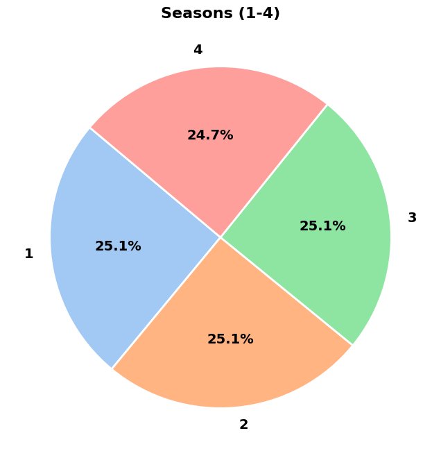

```python
plot_pie_chart(df, 'season', 'Seasons (1-4)')
```

From the 2 years data, the seasons are fairly distributed

```python
x = df.groupby(['year', 'month', 'day_of_week', 'hour'])['datetime'].count()
```

```python
full_date_range = pd.date_range(start = df['datetime'].min(), end=df['datetime'].max(), freq='h')
missing_dates = full_date_range[full_date_range.isin(df['datetime']) == False]
missing_dates
```

```
DatetimeIndex(['2011-01-02 05:00:00', '2011-01-03 02:00:00',
               '2011-01-03 03:00:00', '2011-01-04 03:00:00',
               '2011-01-05 03:00:00', '2011-01-06 03:00:00',
               '2011-01-07 03:00:00', '2011-01-11 03:00:00',
               '2011-01-11 04:00:00', '2011-01-12 03:00:00',
               ...
               '2012-11-30 14:00:00', '2012-11-30 15:00:00',
               '2012-11-30 16:00:00', '2012-11-30 17:00:00',
               '2012-11-30 18:00:00', '2012-11-30 19:00:00',
               '2012-11-30 20:00:00', '2012-11-30 21:00:00',
               '2012-11-30 22:00:00', '2012-11-30 23:00:00'],
              dtype='datetime64[ns]', length=6370, freq=None)
```

The date time is not continuous (every hour for 2 years). From the shape of above output, we have 6370 missing entries

```python
df['hourly_diff'] = df['datetime'].diff().dt.total_seconds() / 3600
df[df['hourly_diff'] >= 2]
```

|  | datetime | season | holiday | workingday | weather | temp | atemp | humidity | windspeed | casual | registered | count | year | month | day_of_week | hour | hourly_diff |
| --- | --- | --- | --- | --- | --- | --- | --- | --- | --- | --- | --- | --- | --- | --- | --- | --- | --- |
| 29 | 2011-01-02 06:00:00 | 1 | 0 | 0 | 3 | 17.22 | 21.210 | 77 | 19.9995 | 0 | 2 | 2 | 2011 | 1 | 6 | 6 | 2.0 |
| 49 | 2011-01-03 04:00:00 | 1 | 0 | 1 | 1 | 6.56 | 6.820 | 47 | 26.0027 | 0 | 1 | 1 | 2011 | 1 | 0 | 4 | 3.0 |
| 72 | 2011-01-04 04:00:00 | 1 | 0 | 1 | 1 | 5.74 | 9.090 | 63 | 6.0032 | 0 | 2 | 2 | 2011 | 1 | 1 | 4 | 2.0 |
| 95 | 2011-01-05 04:00:00 | 1 | 0 | 1 | 1 | 9.84 | 11.365 | 48 | 15.0013 | 0 | 2 | 2 | 2011 | 1 | 2 | 4 | 2.0 |
| 118 | 2011-01-06 04:00:00 | 1 | 0 | 1 | 2 | 6.56 | 9.850 | 64 | 6.0032 | 0 | 1 | 1 | 2011 | 1 | 3 | 4 | 2.0 |
| ... | ... | ... | ... | ... | ... | ... | ... | ... | ... | ... | ... | ... | ... | ... | ... | ... | ... |
| 9063 | 2012-09-01 00:00:00 | 3 | 0 | 0 | 1 | 30.34 | 34.090 | 62 | 7.0015 | 22 | 146 | 168 | 2012 | 9 | 5 | 0 | 289.0 |
| 9519 | 2012-10-01 00:00:00 | 4 | 0 | 1 | 1 | 18.86 | 22.725 | 72 | 7.0015 | 6 | 39 | 45 | 2012 | 10 | 0 | 0 | 265.0 |
| 9975 | 2012-11-01 00:00:00 | 4 | 0 | 1 | 1 | 14.76 | 18.180 | 57 | 6.0032 | 8 | 52 | 60 | 2012 | 11 | 3 | 0 | 289.0 |
| 10146 | 2012-11-08 04:00:00 | 4 | 0 | 1 | 2 | 12.30 | 14.395 | 45 | 19.0012 | 1 | 9 | 10 | 2012 | 11 | 3 | 4 | 2.0 |
| 10430 | 2012-12-01 00:00:00 | 4 | 0 | 0 | 1 | 10.66 | 15.150 | 81 | 0.0000 | 9 | 99 | 108 | 2012 | 12 | 5 | 0 | 265.0 |

65 rows × 17 columns

```python
df[df['hourly_diff'] >=2]['hourly_diff'].value_counts().sort_values(ascending=True)
```

| hourly_diff | count |
| --- | --- |
| 217.0 | 1 |
| 241.0 | 1 |
| 13.0 | 1 |
| 3.0 | 5 |
| 265.0 | 8 |
| 289.0 | 13 |
| 2.0 | 36 |

**dtype:** int64

From above table, we can understand that,the most common missing interval is 2 hours. This suggests that short gaps (like 2 hours) are frequent, but some data points are missing for very long periods (9–12 days).

Let's understand if the large gaps (missing dates more than half-aday) is uniformly distributed or repeating on certain days

```python
df['daily_diff'] = df['hourly_diff'] / 24
date_gaps = df[df['hourly_diff'] >= 2][['datetime','daily_diff','holiday','workingday','season','humidity','windspeed','count','hourly_diff']]
date_gaps = date_gaps[date_gaps['datetime'] > '2011-01-31']  # Exclude Jan 2011
date_gaps = date_gaps[date_gaps['daily_diff']>=0.5]
date_gaps
```

|  | datetime | daily_diff | holiday | workingday | season | humidity | windspeed | count | hourly_diff |
| --- | --- | --- | --- | --- | --- | --- | --- | --- | --- |
| 431 | 2011-02-01 | 12.041667 | 0 | 1 | 1 | 64 | 7.0015 | 8 | 289.0 |
| 877 | 2011-03-01 | 9.041667 | 0 | 1 | 1 | 70 | 31.0009 | 7 | 217.0 |
| 1323 | 2011-04-01 | 12.041667 | 0 | 1 | 2 | 100 | 11.0014 | 6 | 289.0 |
| 1778 | 2011-05-01 | 11.041667 | 0 | 0 | 2 | 67 | 6.0032 | 96 | 265.0 |
| 2234 | 2011-06-01 | 12.041667 | 0 | 1 | 2 | 79 | 11.0014 | 34 | 289.0 |
| 2690 | 2011-07-01 | 11.041667 | 0 | 1 | 3 | 50 | 0.0000 | 68 | 265.0 |
| 3146 | 2011-08-01 | 12.041667 | 0 | 1 | 3 | 70 | 15.0013 | 29 | 289.0 |
| 3602 | 2011-09-01 | 12.041667 | 0 | 1 | 3 | 78 | 7.0015 | 51 | 289.0 |
| 4055 | 2011-10-01 | 11.041667 | 0 | 0 | 4 | 63 | 26.0027 | 130 | 265.0 |
| 4510 | 2011-11-01 | 12.041667 | 0 | 1 | 4 | 87 | 11.0014 | 21 | 289.0 |
| 4966 | 2011-12-01 | 11.041667 | 0 | 1 | 4 | 52 | 22.0028 | 20 | 265.0 |
| 5422 | 2012-01-01 | 12.041667 | 0 | 0 | 1 | 66 | 0.0000 | 48 | 289.0 |
| 5875 | 2012-02-01 | 12.041667 | 0 | 1 | 1 | 38 | 19.0012 | 31 | 289.0 |
| 6330 | 2012-03-01 | 10.041667 | 0 | 1 | 1 | 94 | 0.0000 | 11 | 241.0 |
| 6785 | 2012-04-01 | 12.041667 | 0 | 0 | 2 | 76 | 16.9979 | 67 | 289.0 |
| 7239 | 2012-05-01 | 11.041667 | 0 | 1 | 2 | 59 | 12.9980 | 35 | 265.0 |
| 7695 | 2012-06-01 | 12.041667 | 0 | 1 | 2 | 50 | 16.9979 | 86 | 289.0 |
| 8151 | 2012-07-01 | 11.041667 | 0 | 0 | 3 | 66 | 0.0000 | 149 | 265.0 |
| 8607 | 2012-08-01 | 12.041667 | 0 | 1 | 3 | 79 | 11.0014 | 47 | 289.0 |
| 9063 | 2012-09-01 | 12.041667 | 0 | 0 | 3 | 62 | 7.0015 | 168 | 289.0 |
| 9519 | 2012-10-01 | 11.041667 | 0 | 1 | 4 | 72 | 7.0015 | 45 | 265.0 |
| 9975 | 2012-11-01 | 12.041667 | 0 | 1 | 4 | 57 | 6.0032 | 60 | 289.0 |
| 10430 | 2012-12-01 | 11.041667 | 0 | 0 | 4 | 81 | 0.0000 | 108 | 265.0 |

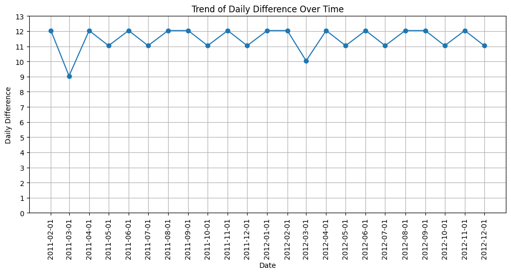

```python
plt.figure(figsize=(12, 5))
plt.plot(date_gaps['datetime'], date_gaps['daily_diff'], marker='o', linestyle='-')
plt.xlabel("Date")
plt.ylabel("Daily Difference")
plt.title("Trend of Daily Difference Over Time")
plt.xticks(df[df['daily_diff'] >=1]['datetime'], rotation=90)
plt.yticks(range(0,14))
plt.grid()
plt.show()
```

Does missing dates areuniform across all days of month?

Null Hypothesis (H₀): The gaps are uniformly distributed across all days of the month (1–31), i.e., no monthly repeating pattern. Alternative Hypothesis (H₁): The gaps are not uniformly distributed and cluster on specific days (e.g., the 1st), indicating a repeating monthly pattern.

alpha = 0.05

```python
date_gaps[['datetime','daily_diff']]
```

|  | datetime | daily_diff |
| --- | --- | --- |
| 431 | 2011-02-01 | 12.041667 |
| 877 | 2011-03-01 | 9.041667 |
| 1323 | 2011-04-01 | 12.041667 |
| 1778 | 2011-05-01 | 11.041667 |
| 2234 | 2011-06-01 | 12.041667 |
| 2690 | 2011-07-01 | 11.041667 |
| 3146 | 2011-08-01 | 12.041667 |
| 3602 | 2011-09-01 | 12.041667 |
| 4055 | 2011-10-01 | 11.041667 |
| 4510 | 2011-11-01 | 12.041667 |
| 4966 | 2011-12-01 | 11.041667 |
| 5422 | 2012-01-01 | 12.041667 |
| 5875 | 2012-02-01 | 12.041667 |
| 6330 | 2012-03-01 | 10.041667 |
| 6785 | 2012-04-01 | 12.041667 |
| 7239 | 2012-05-01 | 11.041667 |
| 7695 | 2012-06-01 | 12.041667 |
| 8151 | 2012-07-01 | 11.041667 |
| 8607 | 2012-08-01 | 12.041667 |
| 9063 | 2012-09-01 | 12.041667 |
| 9519 | 2012-10-01 | 11.041667 |
| 9975 | 2012-11-01 | 12.041667 |
| 10430 | 2012-12-01 | 11.041667 |

```
Chi-Square Statistic: 690.0000
P-Value: 5.9621e-126
Reject H₀: Gaps cluster on specific days, suggesting a repeating pattern.
```

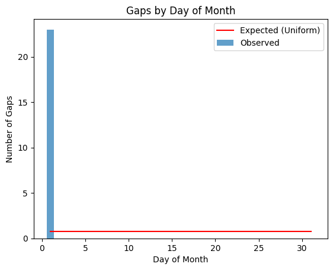

```python
# Extract day of month
date_gaps['day_of_month'] = date_gaps['datetime'].dt.day # we get day 1 for all months because that's where all the missing values are present

# Observed frequencies (all gaps on day 1)
observed = date_gaps['day_of_month'].value_counts().reindex(range(1,32)).fillna(0).astype(int)
observed_counts = observed.values

# Expected frequencies (uniform across 31 days)
total_gaps = len(date_gaps)  # 23
expected_freq = total_gaps / 31  # 23 / 31 ≈ 0.7419
expected = [expected_freq] * 31

# Chi-Square test
chi_stat, p_value = stats.chisquare(observed_counts, f_exp=expected)

# Results
print(f"Chi-Square Statistic: {chi_stat:.4f}")
print(f"P-Value: {p_value:.4e}")
if p_value > 0.05:
    print("Fail to reject H₀: Gaps are uniformly distributed across days.")
else:
    print("Reject H₀: Gaps cluster on specific days, suggesting a repeating pattern.")

# Plot observed vs expected
plt.bar(range(1, 32), observed_counts, label='Observed', alpha=0.7)
plt.plot(range(1, 32), expected, 'r-', label='Expected (Uniform)')
plt.xlabel('Day of Month')
plt.ylabel('Number of Gaps')
plt.title('Gaps by Day of Month')
plt.legend()
plt.show()
```

Insights: As we can see p value is very small suggesting a repeating pattern in missing days

```python
df.drop(['hourly_diff', 'daily_diff'], axis=1, inplace=True)
df.columns
```

```
Index(['datetime', 'season', 'holiday', 'workingday', 'weather', 'temp',
       'atemp', 'humidity', 'windspeed', 'casual', 'registered', 'count',
       'year', 'month', 'day_of_week', 'hour'],
      dtype='object')
```

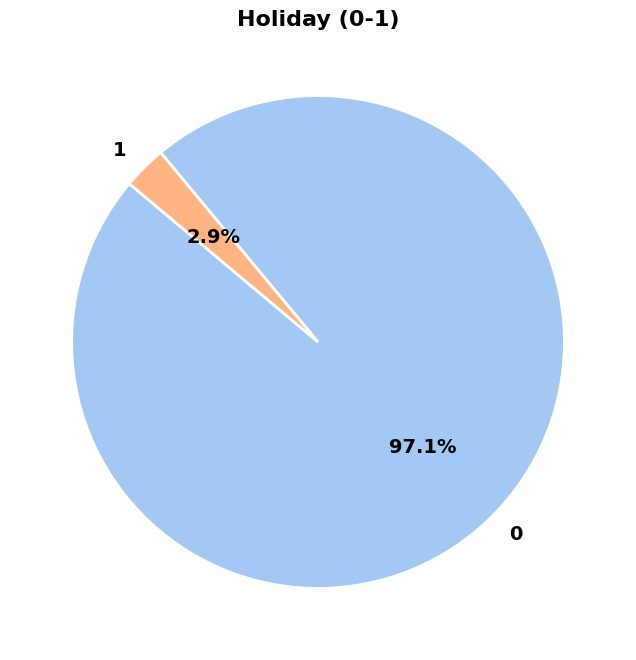

```python
plot_pie_chart(df, 'holiday', 'Holiday (0-1)') # 0 - not a holiday, 1 - holiday
```

Most of the days are working days - data is heavily right skewed

[figure not shown]

```python
plot_pie_chart(df, 'workingday', 'workingday (0-1)') # 0 - holiday or weekend, 1 - working day
```

From this pie chart, we can tell that working day is midly skewed to the right

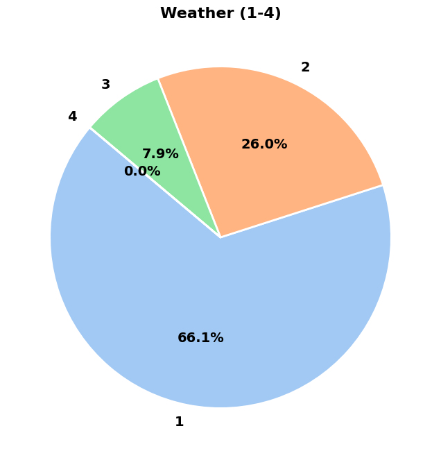

```python
plot_pie_chart(df, 'weather', 'Weather (1-4)')

# 1: Clear, Few clouds, partly cloudy, partly cloudy
# 2: Mist + Cloudy, Mist + Broken clouds, Mist + Few clouds, Mist
# 3: Light Snow, Light Rain + Thunderstorm + Scattered clouds, Light Rain + Scattered clouds
# 4: Heavy Rain + Ice Pallets + Thunderstorm + Mist, Snow + Fog
```

```python
df['weather'].value_counts()
```

| weather | count |
| --- | --- |
| 1 | 7192 |
| 2 | 2834 |
| 3 | 859 |
| 4 | 1 |

**dtype:** int64

Insights: 4 - Heavyrain is 0% in above graph because it occured only once in 2 years

```python
numerical_cols = [col for col in numerical_cols if col != 'datetime'] # ommiting datetime col
numerical_cols
```

```
['temp', 'atemp', 'humidity', 'windspeed', 'casual', 'registered', 'count']
```

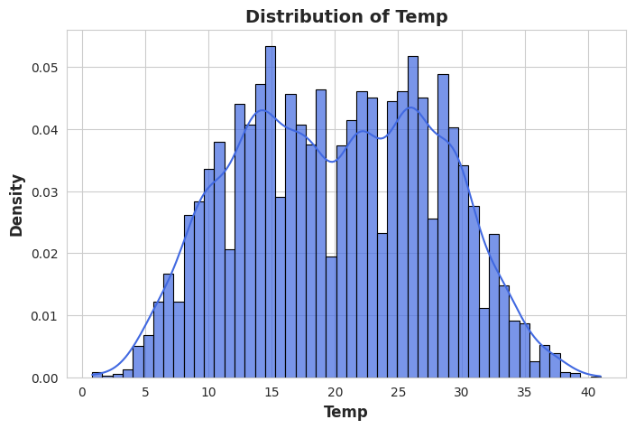

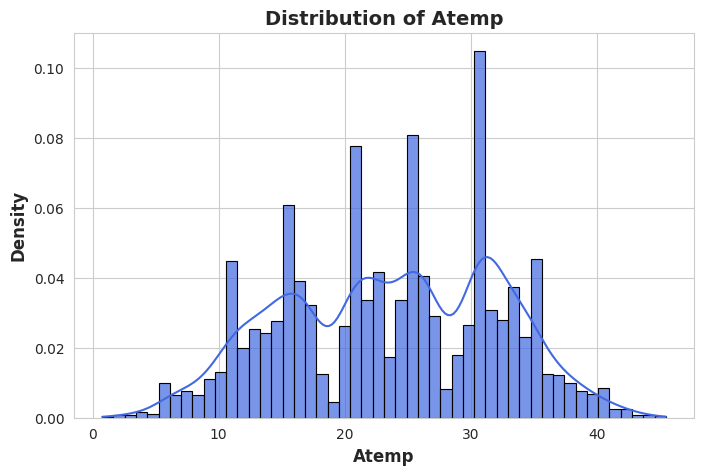

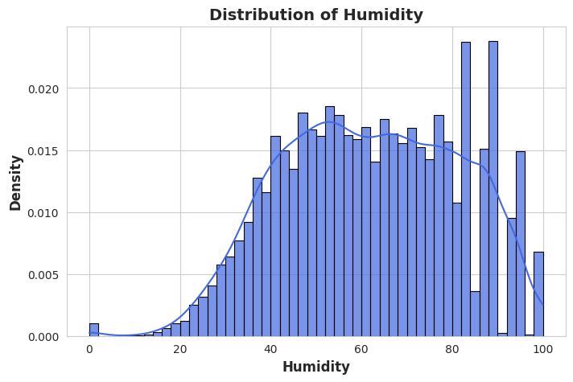

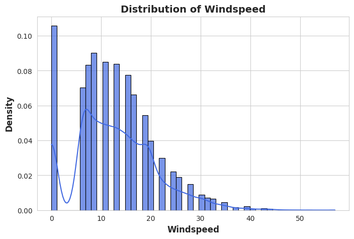

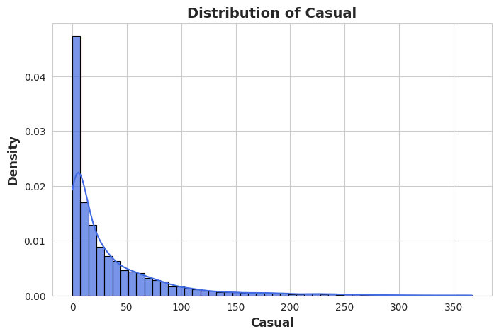

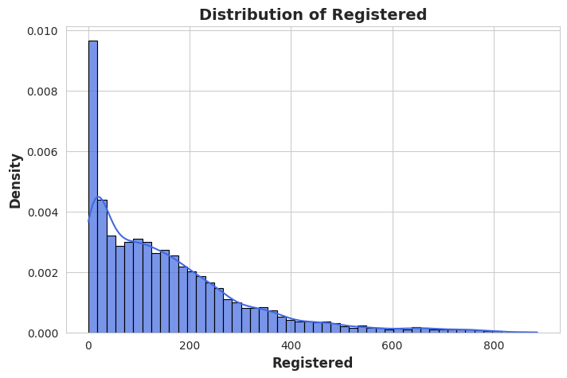

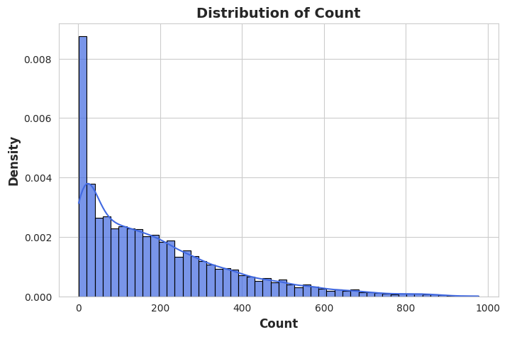

```python
def plot_histogram(data, column, bins=50, kde=True, color='royalblue', alpha=0.7):
    # Set style
    sns.set_style("whitegrid")

    # Create figure
    plt.figure(figsize=(8, 5))

    # Plot histogram
    sns.histplot(data[column], bins=bins, kde=kde, color=color, alpha=alpha, edgecolor='black', stat="density")

    # Labels and title
    plt.xlabel(column.replace('_', ' ').title(), fontsize=12, fontweight='bold')
    plt.ylabel("Density", fontsize=12, fontweight='bold')
    plt.title(f"Distribution of {column.replace('_', ' ').title()}", fontsize=14, fontweight='bold')

    # Show plot
    plt.show()

for col in numerical_cols:
    plot_histogram(df, col)
```